# Week 5 R Exercises - Solutions

2020-09-01

# 1 Question 1: A simple Gibbs sampler example

Suppose that we need to sample from the following joint distribution
$$f(x,y|α,β)∝(nx)yx+α−1(1−y)n−x+β−1$$
where $x=0,1,…,n$, $0≤y≤1$ with $α,β>0$.

From the above equation,
$$π(x|y)∝(nx)yx(1−y)n−x$$
such that
$$X|Y∼Bin(n,y).$$
Similarly,
$$Y|X∼Beta(x+α,n−x+β).$$
Posterior samples can be obtained from $f(x,y|α,β)$ by sampling from $X|Y$ and $Y|X$ in turn.

Let $n=16$, $α=2$ and $β=10$. The following code can now be used to sample from $f(x,y|α,β)$. Note that only the samples for $X$ are retained here.

*1. Change the following code so as to obtain the marginal posterior distribution of $y$.*

Simply change what variable is returned.

```r
sample_x2<-function(k=10000,
                    start.x=sample(1:16, size=1),
                    start.y=runif(1)){
  #k = the length of a Gibbs sequence!
  #start.x and start.y are the starting values of x and y
  #these are random values

  n<-16; alpha<-2; beta<-10

  #starting valkue of y
  x<-NULL; y<-NULL
  y[1]<-start.y #starting values
  x[1]<-start.x #starting values

  for (i in 2:k){
    x[i]<-rbinom(n=1, size=n, prob=y[i-1])
    y[i]<-rbeta(n=1, shape1= (x[i]+alpha), shape2= (n-x[i]+beta))
  }

  #return x
  return(y)
}
```

*2. Thereafter run the code three times (called chains). Store the three sets of results.*

```r
chain1 <- sample_x2(k=20000, start.x=sample(1:16, size=1), start.y=runif(1))
chain2 <- sample_x2(k=20000, start.x=sample(1:16, size=1), start.y=runif(1))
chain3 <- sample_x2(k=20000, start.x=sample(1:16, size=1), start.y=runif(1))
```

*3. Plot the trace plots related to $[y]$ on the same figure. What do you notice?*

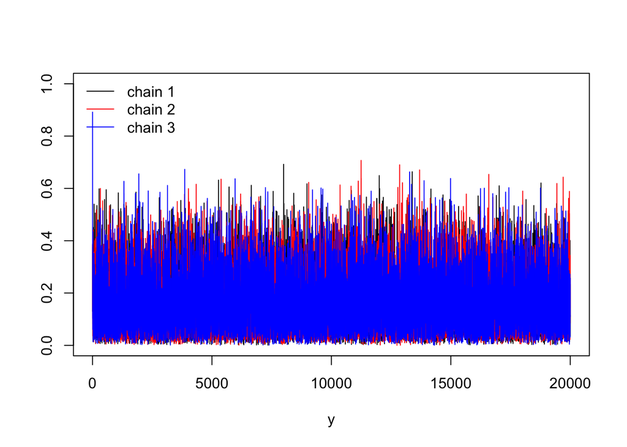

```r
plot(chain1, xlab="y", ylim=c(0,1), type="l", ylab="")
lines(chain2, xlab="y", col="red")
lines(chain3, xlab="y", col="blue")
legend("topleft", legend=c("chain 1", "chain 2", "chain 3"), col=c("black", "red", "blue"), lty=rep(1), bty="n")
```

When running any MCMC analysis, we want all our chains to explore the *posterior distribution adequately*. This means that if one uses random starting values that all of the chains should converge to the stationary distribution (which is the posterior distribution of the parameters of our model). Hopefully this happens fairly rapidly although in any problem we never know exactly how many MCMC iterations will be required at the start of an analysis.

In this example we see that the three chains converge to the stationary distribution very quickly. We say that the chains ‘mix well’ when all chains tends to the stationary distribution *quickly*.

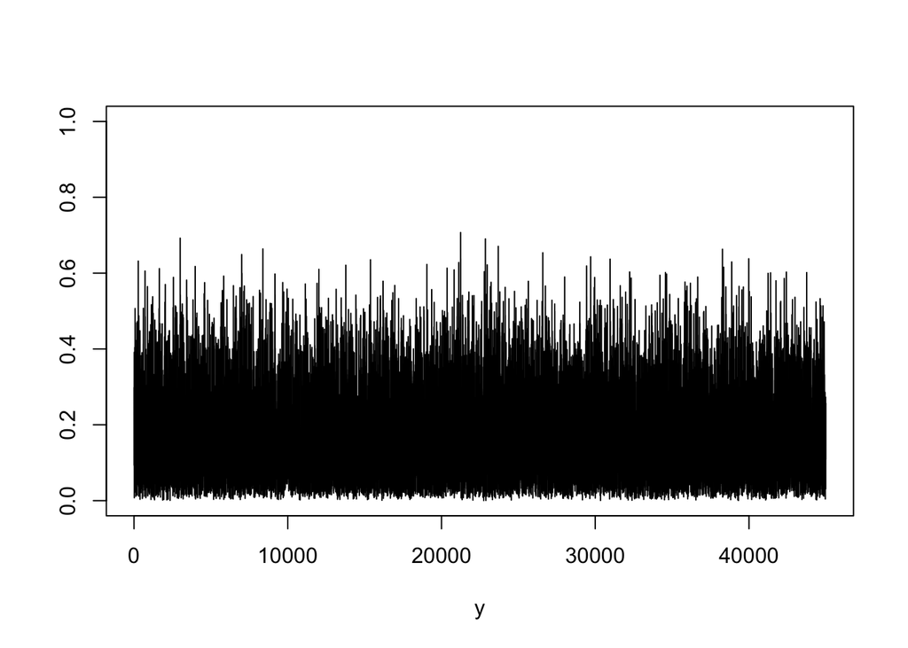

```r
y.samples <- c(chain1[-c(1:5000)], chain2[-c(1:5000)], chain3[-c(1:5000)])
plot(y.samples, xlab="y", ylim=c(0,1), type="l", ylab="")
```

*5. Plot the histogram and autocorrelation function of ‘the’y.samples’. Comment on your results.*

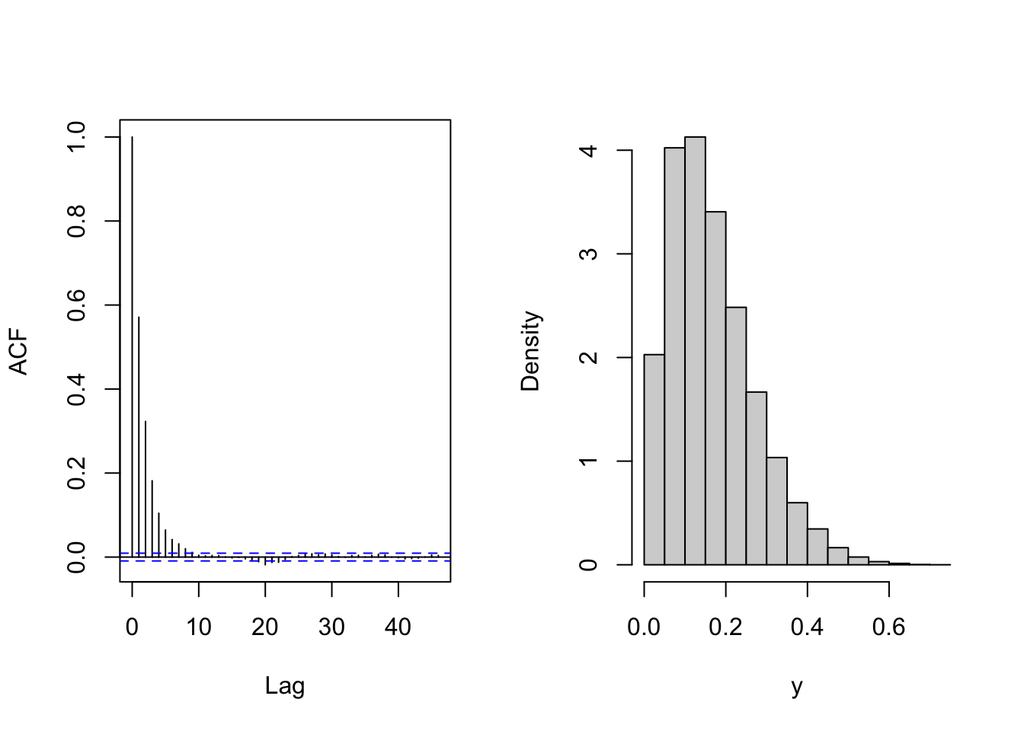

```r
par(mfrow=c(1,2))
acf(y.samples, main="")
hist(y.samples, main="", xlab="y", prob=TRUE)
```

The chains are serially correlated (which is ok, since they were created using a Markov chain). The marginal distribution is skewed to the right. See if you can work out the marginal distribution analytically.

# 2 Question 2: The Bayesian Linear model

## 2.1 Simulate data some regression data.

```r
#Lets simulate some data
set.seed(1)
n <- 150
X.c <- data.frame(matrix(rnorm(5*n), ncol=5))
colnames(X.c) <- c("X1", "X2", "X3", "X4", "X5")

X <- as.matrix(cbind(1, X.c))
e <- matrix(rnorm(n), ncol=1)

beta.true <- matrix(c(1, 0, 10, 0, 2, -3), ncol=1)
Y <- X%*%beta.true + e
```

## 2.2 The OLS results

```r
fit1 <-lm(Y~ X1 + X2 + X3 + X4 + X5, data=X.c)
summary(fit1)
```

```
##
## Call:
## lm(formula = Y ~ X1 + X2 + X3 + X4 + X5, data = X.c)
##
## Residuals:
##      Min       1Q   Median       3Q      Max
## -2.65555 -0.75505  0.00037  0.79276  2.99348
##
## Coefficients:
##              Estimate Std. Error t value Pr(>|t|)
## (Intercept)  0.993211   0.089175  11.138   <2e-16 ***
## X1          -0.023844   0.098598  -0.242    0.809
## X2          10.052046   0.086969 115.582   <2e-16 ***
## X3           0.002165   0.086479   0.025    0.980
## X4           2.101651   0.083887  25.053   <2e-16 ***
## X5          -3.015520   0.080422 -37.496   <2e-16 ***
## ---
## Signif. codes:  0 '***' 0.001 '**' 0.01 '*' 0.05 '.' 0.1 ' ' 1
##
## Residual standard error: 1.084 on 144 degrees of freedom
## Multiple R-squared:  0.9911, Adjusted R-squared:  0.9908
## F-statistic:  3194 on 5 and 144 DF,  p-value: < 2.2e-16
```

## 2.3 Bayesian fit of the full model

Assume that the design matrix $XX$ is an $n×(k+1)$ matrix, such that there are $2k$ possible regression models to fit to the data (an intercept is included in all models). Define $γγ∈Γ={0,1}k$ as a binary vector which indicates which model is being fit to the data. e.g. if $γγ=c(1,0,1,…,0)$ only $X1$ and $X3$ are included in the model. The associated design matrix is $XXγγ$ such that the fitted model is $YY=XXγγββγγ+ee.$

Lets assume that $γγ=c(1,1,1,1,1)$ such that we include all covariates in the regression model. Assume that the following prior distributions are specified
$$ββγγ|c,σ2∼N(00,cσ2(XXγγTXXγγ)−1)π(σ2)∝1σ2π(c)=1cIN(c)γγ=0.5k.$$

During the course of the semester were able to derive the marginal distribution of $ββ|yy$. In many real world applications we are unable to analytically work this out and will have to rely on some other techniques. Below we use the **Gibbs sampler** in order to obtain the marginal distribution of $ββ|yy$.

The following conditional posteriors distributions can easily be obtained (be able to show this!):
$$ββγγ|c,σ2,yy∼N(c1+cββ^,σ2c1+c(XXγγTXXγγ)−1)σ2|ββγγ,c,yy∼IG(n+k+12,12((yy−XXγγββγγ)T(yy−XXγγββγγ)+1cββγγTXXγγTXXγγββγγ))[c|ββγγ,σ2,yy]=c−(qγk+3)/2exp(−RRγγ2c)∑jj−(qγγ+3)/2exp(−RRγγ2j)$$
where
$$RRγγ=1σ2ββγγTXXγγTXXγγββγγ$$
and $qγk$ is the number of explanatory variables included in the model.

*1. Provide an expression for $[c|ββγγ,σ2,yy,XX]$.*
$$c|ββγγ,σ2,yy,XX∝[c][ββγγ|c,σ2,yy,XX]IN(c)∝1cc−(qγγ+1)/2exp(−12cRRγγ)IN(c)∝c−(qγγ+3)/2exp(−12cRRγγ)IN(c)=c−(qγγ+3)/2exp(−12cRRγγ)∑j=1∞j−(qγγ+3)/2exp(−12jRRγγ)$$

*2. Explain how one can sample from $[c|ββγγ,σ2,yy,XX]$.*

$[c|ββγγ,σ2,yy,XX]$ is thus a mass function. If we truncate the infinite sum to $20000$ then we can easily sample from this mass function. Below the conditional distribution is explicitly written for some values of $c$:
$$p(c|ββγγ,σ2,yy,XX)={exp(−12RRγγ)∑j=120000j−(qγγ+3)/2exp(−12jRRγγ)ifc=12−(qγγ+3)/2exp(−12×2RRγγ)∑j=120000j−(qγγ+3)/2exp(−12jRRγγ)ifc=210000−(qγγ+3)/2exp(−12×10000RRγγ)∑j=120000j−(qγγ+3)/2exp(−12×10000RRγγ)ifc=1000020000−(qγγ+3)/2exp(−12×20000RRγγ)∑j=120000j−(qγγ+3)/2exp(−12×20000RRγγ)ifc=20000$$

We can thus use the ‘sample’ command to sample from the above mass function! Note that $c$ is discrete and thus $[c|.]$ is not an inverse gamma distribution!

*3. Use the above conditional posterior distributions in order to obtain posterior samples ($10000$) of $[ββγγ,σ2,c|yy,XX]$.*

```r
#the number of iterations
nsims <- 20000
#discard half of the iterations
keep.index <- floor(nsims/2):nsims

k <- 5 #the number of covariates (q_gamma)

#used for sampling from a multivariate normal
#you can use other packages if you like
#mvrnorm
require(MASS)
#the ols estimate of beta
b.ols <- solve(crossprod(X))%*%t(X)%*%Y
C.lam <- solve(crossprod(X))

#truncate the infinite sum to 20000
c.index <- 1:20000

#set some starting values c, sigma2
#any random allowable number
c. <- 5
sigma2 <- 1

const1 <- -(k+3)/2

#create objects to store the posterior samples
beta.sims <- matrix(0, nrow=nsims, ncol=k+1)
sigma2.sims <- matrix(sigma2, nrow = nsims)
c.sims <- matrix(c., nrow = nsims)

#put the sampling code in a for loop
#start at isims=2
for (isims in 2:nsims){
  #sampling can be rather slow at times!

  #simulate 'beta' and store it in beta.sim
  #use the 'mvrnorm' function in the MASS package
  #take note the indexing for 'c.sims' and 'sigma2.sims'
  beta.sims[isims, ] <- mvrnorm(n=1, mu = b.ols*c.sims[isims-1]/(1+c.sims[isims-1]),
                               Sigma = sigma2.sims[isims-1]*c.sims[isims-1]/(1+c.sims[isims-1])*C.lam)

  #simulate 'sigma2' and store it in sigma2
  #have a look at the way R specifies 'rgamma'
  #I am using the 'rgamma' function in baseR
  rate.param <- ( crossprod(Y-X%*%beta.sims[isims, ]) + crossprod(X%*%beta.sims[isims, ])/c.sims[isims-1] )[1]/2
  sigma2.sims[isims] <- 1/rgamma(1, shape = (n+k+1)/2, rate =rate.param)

  #simulate the value of 'c'
  #think about how to do this!!!
  #truncate the infinite sum to 10000
  R.lam <- (crossprod(X%*%beta.sims[isims, ])/sigma2.sims[isims])[1]

  #the unstable solution
  #num <- (c.index^(const1))*exp( -R.lam*.5/c.index )
  #c.dens <- num/sum(num)

  #it is more stable to use logs
  log.num <- const1*log(c.index) - R.lam*.5/c.index
  max.log.c <- max(log.num)
  log.num2 <- exp( log.num - max.log.c)
  c.dens <- log.num2/sum(log.num2)

  c.sims[isims] <- sample(x=c.index, size=1, prob = c.dens)
}
```

Take note of how
$$c−(qγγ+3)/2exp(−12cRRγγ)$$
was calculated above!

*What do the trace plots look like?*

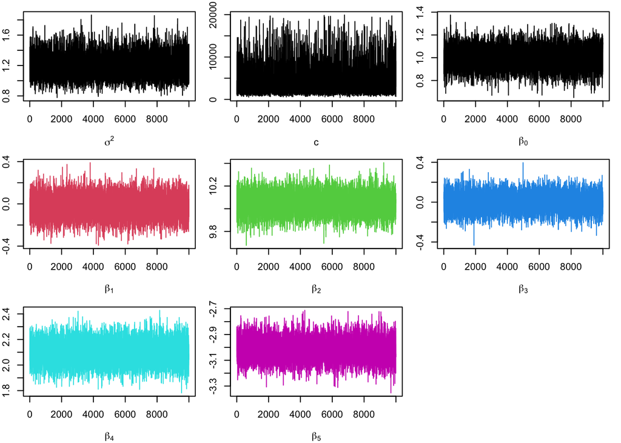

```r
par(mfrow=c(3,3), mar=c(4,2,1,1))
plot(sigma2.sims[keep.index], type="l", xlab=expression(sigma^2), ylab="")
plot(c.sims[keep.index], type="l", xlab="c", ylab="")

for (i in 1:6){
  plot(beta.sims[keep.index, i], type="l", xlab=bquote(beta[.(i-1)]), ylab="", col=i)
}
```

In general you want the regression parameters to look something like the above plots. They are stationary series. Plots of non-negative parameters are often *less-stationary* looking, e.g. the plot for $c$; but they are correct. If your chains mix well, you want the trace plots for each of your chains to lie *on-top of each other*. This **suggests** that the chains have converged to the posterior distribution. Later in the course we will learn how to test whether this is in fact true.

*Plot the histograms of all of your parameters. Comment on the 95% credibility interval. Are the results similar to those obtained using least squares?*

This you should be able to do fairly easily!

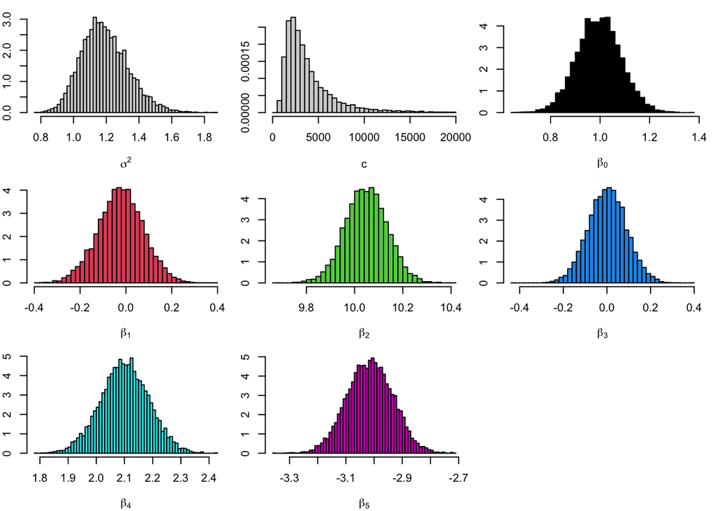

```r
par(mfrow=c(3,3), mar=c(4,2,1,1))
hist(sigma2.sims[keep.index], prob=TRUE, xlab=expression(sigma^2), ylab="", main="", breaks=50)
hist(c.sims[keep.index], prob= TRUE, xlab="c", ylab="", main="", breaks=50)

for (i in 1:6){
  hist(beta.sims[keep.index, i], prob=TRUE, xlab=bquote(beta[.(i-1)]), ylab="", main="", breaks=50, col=i)
}
```

*Compare the marginal posterior mean for the $β$ coefficients to those obtained analytically. Do they agree?*

```r
#your results might differ slighly
#beta means
apply(beta.sims[keep.index,], 2, mean)
```

```
## [1]  0.995202307 -0.022447959 10.048348419  0.001865634  2.100550640
## [6] -3.014441243
```

Recall that
$$E(ββ|yy,XX)=E(E(ββ|yy,XX,c)|yy,XX)=E(cc+1ββ^|yy,XX)=(∑c=1∞c1+c[yy|XX,c)]1c∑c=1∞[yy|XX,c]1c)ββ^=(∑c=1∞11+c[yy|XX,c]∑c=1∞[yy|XX,c]1c)ββ^$$
where
$$[yy|XX,c]=(c+1)−(qγγ+1)/2π−n/2Γ(n/2)A2−n/2$$
and
$$A2=yyTyy−c1+cyyTXXγγ(XXγγTXXγγ)−1XXγγTyy$$
After some simplification we have
$$E(ββ|yy,XX)=(∑c=1∞(1+c)−(qγγ+3)/2A2−n/2∑c=1∞1c(1+c)−(qγγ+1)/2A2−n/2)ββ^.$$
Below I use logs to calculate both of the sums.

```r
#calculation of the marginal expectation of beta

#the ols estimator
#beta.ols <- solve( crossprod(X))%*%t(X)%*%Y )

beta.ols <- solve( crossprod(X), crossprod(X, Y) )
mat_const1 <- crossprod(Y, X) #t(Y) %*% X
const2 <- crossprod(Y, Y)[1]
const3 <- (mat_const1%*%beta.ols)[1]

#note the difference in computational speed
#mainly when t(X)%*%X is a large matrix
# n2 <- 10000
# X.c2 <- data.frame(matrix(rnorm(50*n2), ncol=50))
# Xd <- as.matrix(cbind(1, X.c2))
# ed <- matrix(rnorm(n2), ncol=1)
# beta.true2 <- matrix(runif(51), ncol=1)
# Yd <- Xd%*%beta.true2 + ed
# system.time(solve( t(Xd)%*%Xd )%*%t(Xd)%*%Yd )
# system.time(solve( crossprod(Xd))%*%t(Xd)%*%Yd )
# system.time(solve( crossprod(Xd), crossprod(Xd, Yd) ))

#recall
#const1 <- -(k+3)/2

log.A2 <- log(const2 - const3*c.index/(1+c.index))
num.logs <- const1*log(1+c.index) -0.5*n*log.A2
den.logs <- -log(c.index) - ((k+1)/2)*log(1+c.index) -0.5*n*log.A2
stab.const <- exp( max(num.logs) - max(den.logs) )

beta.mar.const <- sum( exp(num.logs - max(num.logs)) ) * stab.const / sum( exp(den.logs - max(den.logs)) )

#the same constant
#in this problem the calculations appear to be quite stable
#sum(((1+c.index)^const1)*( (const2 - const3*c.index/(1+c.index))^(-n/2)))/sum((1/c.index)*((1+c.index)^(- ((k+1)/2)))*( (const2 - const3*c.index/(1+c.index))^(-n/2)))


df <- as.data.frame(cbind(beta.mar.const*beta.ols, beta.ols))
colnames(df) <- c("mcmc.Beta.mean", "ols")
df
```

```
##    mcmc.Beta.mean          ols
## 1     0.992839435  0.993211471
## X1   -0.023834715 -0.023843646
## X2   10.048281165 10.052046449
## X3    0.002164274  0.002165085
## X4    2.100864134  2.101651368
## X5   -3.014390301 -3.015519851
```

Notice that the marginal posterior means of $ββ$ is very similar to those obtained when using least squares.

*What is the posterior median for $c$?*

```r
#You might well get something slightly different.
median(c.sims[keep.index])
```

```
## [1] 3037
```

We know that $π(c)$ is actually a mass function.

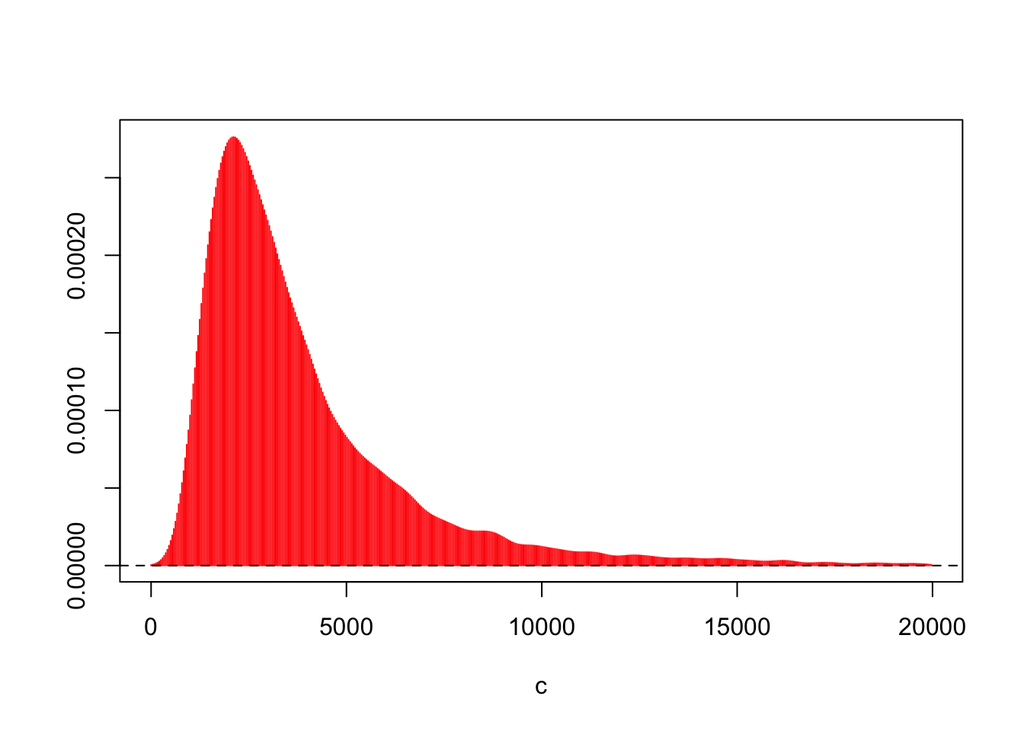

```r
d.c <- density(c.sims[keep.index])
keep.d <- which(d.c$x>0 & d.c$x<=max(c.index))
plot(d.c$x[keep.d], d.c$y[keep.d], main="", xlab="c", col="red", type="h", ylab="")
abline(h=0, lty=2)
```

```r
#prob(c>15000)
#sum(c.sims[keep.index]>15000)/length(keep.index)
```

*Have a look at the autocorrelation function of the retained samples. What do you notice?*

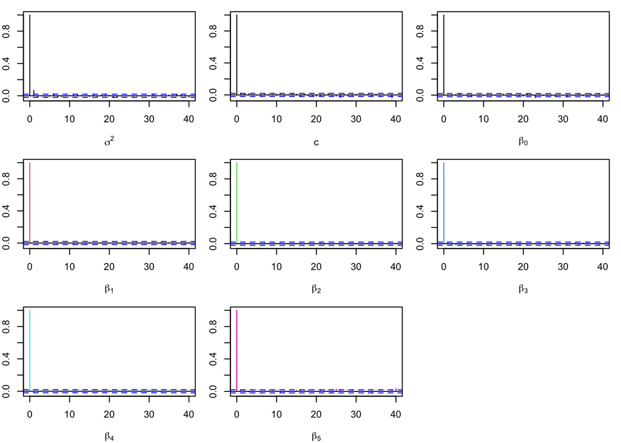

```r
par(mfrow=c(3,3), mar=c(4,2,1,1))
acf(sigma2.sims[keep.index],xlab=expression(sigma^2), ylab="", main="")
acf(c.sims[keep.index],  xlab="c", ylab="", main="")

for (i in 1:6){
  acf(beta.sims[keep.index, i], xlab=bquote(beta[.(i-1)]), ylab="", main="", col=i)
}
```

There is not any significant serial autocorrelation in the samples.

**TAKE NOTE THAT I ONLY RAN ONE CHAIN HERE! ONE SHOULD RUN AT LEAST THREE CHAINS AND THEN ASSESS WHETHER THE CHAINS HAVE CONVEREGED. (More on how to do that will follow later in the course.)**